# Stat 433 Project

Cameron Jones

11/16/2021

# Scroll to bottom to see figure 1!

## Reading Data Into R

### Performance Data

season stats, goals, expected goals, etc., from understat: https://www.kaggle.com/slehkyi/extended-football-stats-for-european-leagues-xg

```r
performanceData = read_csv("ProjectData\\understat.csv")
str(performanceData)
```

```
## spec_tbl_df [684 x 24] (S3: spec_tbl_df/tbl_df/tbl/data.frame)
##  $ ...1        : chr [1:684] "La_liga" "La_liga" "La_liga" "La_liga" ...
##  $ ...2        : num [1:684] 2014 2014 2014 2014 2014 ...
##  $ position    : num [1:684] 1 2 3 4 5 6 7 8 9 10 ...
##  $ team        : chr [1:684] "Barcelona" "Real Madrid" "Atletico Madrid" "Valencia" ...
##  $ matches     : num [1:684] 38 38 38 38 38 38 38 38 38 38 ...
##  $ wins        : num [1:684] 30 30 23 22 23 16 15 13 14 15 ...
##  $ draws       : num [1:684] 4 2 9 11 7 12 10 12 8 4 ...
##  $ loses       : num [1:684] 4 6 6 5 8 10 13 13 16 19 ...
##  $ scored      : num [1:684] 110 118 67 70 71 48 42 47 42 46 ...
##  $ missed      : num [1:684] 21 38 29 32 45 37 41 44 48 68 ...
##  $ pts         : num [1:684] 94 92 78 77 76 60 55 51 50 49 ...
##  $ xG          : num [1:684] 103 95.8 57 55.1 69.5 ...
##  $ xG_diff     : num [1:684] -7.02 -22.23 -9.95 -14.94 -1.47 ...
##  $ npxG        : num [1:684] 97.8 86.1 52.6 49.7 62.1 ...
##  $ xGA         : num [1:684] 28.4 42.6 29.1 39.4 47.9 ...
##  $ xGA_diff    : num [1:684] 7.4443 4.6072 0.0691 7.3926 2.8627 ...
##  $ npxGA       : num [1:684] 24.7 38.9 26.8 33.4 41.9 ...
##  $ npxGD       : num [1:684] 73 47.2 25.7 16.3 20.2 ...
##  $ ppda_coef   : num [1:684] 5.68 10.21 8.98 8.71 8.28 ...
##  $ oppda_coef  : num [1:684] 16.37 12.93 9.24 7.87 9.48 ...
##  $ deep        : num [1:684] 489 351 197 203 305 242 183 287 184 147 ...
##  $ deep_allowed: num [1:684] 114 153 123 172 168 171 171 207 184 219 ...
##  $ xpts        : num [1:684] 94.1 81.7 73.1 63.7 67.4 ...
##  $ xpts_diff   : num [1:684] 0.0813 -10.2511 -4.8647 -13.2932 -8.6133 ...
##  - attr(*, "spec")=
##   .. cols(
##   ..   ...1 = col_character(),
##   ..   ...2 = col_double(),
##   ..   position = col_double(),
##   ..   team = col_character(),
##   ..   matches = col_double(),
##   ..   wins = col_double(),
##   ..   draws = col_double(),
##   ..   loses = col_double(),
##   ..   scored = col_double(),
##   ..   missed = col_double(),
##   ..   pts = col_double(),
##   ..   xG = col_double(),
##   ..   xG_diff = col_double(),
##   ..   npxG = col_double(),
##   ..   xGA = col_double(),
##   ..   xGA_diff = col_double(),
##   ..   npxGA = col_double(),
##   ..   npxGD = col_double(),
##   ..   ppda_coef = col_double(),
##   ..   oppda_coef = col_double(),
##   ..   deep = col_double(),
##   ..   deep_allowed = col_double(),
##   ..   xpts = col_double(),
##   ..   xpts_diff = col_double()
##   .. )
##  - attr(*, "problems")=<externalptr>
```

### Transfer Data

Individual transfers in European soccer leagues as scraped from www.transfermarkt.com, by github user ewenme: https://github.com/ewenme/transfers

```r
rawTransferData = read_csv("https://raw.githubusercontent.com/ewenme/transfers/master/data/2014/english_premier_league.csv")

for (i in 2015:2019) {
  link = paste0("https://raw.githubusercontent.com/ewenme/transfers/master/data/", i, "/english_premier_league.csv")
  data = read_csv(link)
  rawTransferData = bind_rows(rawTransferData, data)
}
str(rawTransferData)
```

```
## spec_tbl_df [5,127 x 12] (S3: spec_tbl_df/tbl_df/tbl/data.frame)
##  $ club_name         : chr [1:5127] "Arsenal FC" "Arsenal FC" "Arsenal FC" "Arsenal FC" ...
##  $ player_name       : chr [1:5127] "Alexis Sánchez" "Calum Chambers" "Danny Welbeck" "Mathieu Debuchy" ...
##  $ age               : num [1:5127] 25 19 23 28 25 22 21 19 22 19 ...
##  $ position          : chr [1:5127] "Centre-Forward" "Centre-Back" "Centre-Forward" "Right-Back" ...
##  $ club_involved_name: chr [1:5127] "FC Barcelona" "Southampton" "Man Utd" "Newcastle" ...
##  $ fee               : chr [1:5127] "£38.25m" "£18.21m" "£18.00m" "£13.50m" ...
##  $ transfer_movement : chr [1:5127] "in" "in" "in" "in" ...
##  $ transfer_period   : chr [1:5127] "Summer" "Summer" "Summer" "Summer" ...
##  $ fee_cleaned       : num [1:5127] 38.2 18.2 18 13.5 3.6 ...
##  $ league_name       : chr [1:5127] "Premier League" "Premier League" "Premier League" "Premier League" ...
##  $ year              : num [1:5127] 2014 2014 2014 2014 2014 ...
##  $ season            : chr [1:5127] "2014/2015" "2014/2015" "2014/2015" "2014/2015" ...
##  - attr(*, "spec")=
##   .. cols(
##   ..   club_name = col_character(),
##   ..   player_name = col_character(),
##   ..   age = col_double(),
##   ..   position = col_character(),
##   ..   club_involved_name = col_character(),
##   ..   fee = col_character(),
##   ..   transfer_movement = col_character(),
##   ..   transfer_period = col_character(),
##   ..   fee_cleaned = col_double(),
##   ..   league_name = col_character(),
##   ..   year = col_double(),
##   ..   season = col_character()
##   .. )
##  - attr(*, "problems")=<externalptr>
```

## Data Cleaning and Preparing

### Transfer Data

```r
transferData = rawTransferData

#adjust data formatting issues
transferData$fee_cleaned[transferData$player_name == "Bertrand Traoré" & transferData$age == 20] = 1.8
transferData$club_name = sub(" FC", "", transferData$club_name)
transferData$club_name[transferData$club_name == "AFC Bournemouth"] = "Bournemouth"
transferData$club_name[transferData$club_name == "Brighton & Hove Albion"] = "Brighton"
transferData$club_name[transferData$club_name == "Cardiff City"] = "Cardiff"
transferData$club_name[transferData$club_name == "Huddersfield Town"] = "Huddersfield"
transferData$club_name[transferData$club_name == "Hull City"] = "Hull"
transferData$club_name[transferData$club_name == "Leicester City"] = "Leicester"
transferData$club_name[transferData$club_name == "Norwich City"] = "Norwich"
transferData$club_name[transferData$club_name == "Stoke City"] = "Stoke"
transferData$club_name[transferData$club_name == "Sunderland AFC"] = "Sunderland"
transferData$club_name[transferData$club_name == "Swansea City"] = "Swansea"
transferData$club_name[transferData$club_name == "Tottenham Hotspur"] = "Tottenham"
transferData$club_name[transferData$club_name == "West Ham United"] = "West Ham"

#filter to summer transfers with fees; control for transfer in or out
transferData$fee_cleaned[transferData$transfer_movement == "out"] = -1 * transferData$fee_cleaned
transferData = transferData %>% filter(transfer_period == "Summer", complete.cases(fee_cleaned))

#Classify by three groups: Attacker, Midfielder, Defender
transferData$positionGroup = "Attacker"
transferData$positionGroup[grepl("Midfield", transferData$position)] = "Midfielder"
transferData$positionGroup[(grepl("Back", transferData$position) | transferData$position == "Goalkeeper")] = "Defender"

#dplyr
transferData = transferData %>% group_by(year, club_name, positionGroup) %>% summarize(netTransferSpend = sum(fee_cleaned), avgAge = mean(age), n = n()) %>% pivot_wider(names_from = positionGroup, values_from = c(netTransferSpend, avgAge, n))

transferData[is.na(transferData)] = 0 #some teams did not buy or sell a certain class of player in a given summer. set these to zero.

transferData = transferData %>% rename(team = club_name) %>% mutate(netTransferSpend_Total = sum(netTransferSpend_Attacker, netTransferSpend_Midfielder, netTransferSpend_Defender))
```

### Performance Data

```r
#Selects the Premier League teams and drops the "league" column.
performanceData = performanceData %>% filter(...1 == "EPL") %>% rename(year = ...2) %>% select(-...1)
```

## Results

```r
finalData = left_join(performanceData, transferData) %>% mutate(avgAge_Overall = avgAge_Attacker * n_Attacker + avgAge_Midfielder * n_Midfielder + avgAge_Defender * n_Defender) %>% select(year, team, xpts, xG, xGA, contains(c("net", "avg", "n_")))

summary(lm(xpts ~ netTransferSpend_Total + avgAge_Overall, data = finalData))
```

```
##
## Call:
## lm(formula = xpts ~ netTransferSpend_Total + avgAge_Overall,
##     data = finalData)
##
## Residuals:
##     Min      1Q  Median      3Q     Max
## -26.223  -9.362  -1.708   7.122  38.291
##
## Coefficients:
##                         Estimate Std. Error t value Pr(>|t|)
## (Intercept)            4.933e+01  3.737e+00  13.202  < 2e-16 ***
## netTransferSpend_Total 1.071e-01  2.061e-02   5.198 8.66e-07 ***
## avgAge_Overall         7.311e-05  4.710e-03   0.016    0.988
## ---
## Signif. codes:  0 '***' 0.001 '**' 0.01 '*' 0.05 '.' 0.1 ' ' 1
##
## Residual standard error: 13.17 on 117 degrees of freedom
## Multiple R-squared:  0.188,  Adjusted R-squared:  0.1741
## F-statistic: 13.55 on 2 and 117 DF,  p-value: 5.114e-06
```

### Figure 1

Here is a scatter plot of net transfer spend in a given summer transfer window versus that team’s expected points in the following season. Net transfer spend is calculated as total spending - total revenue from sales, and expected points is a descriptive statistic from understat.com which models the points a team would be expected to gain (3 points for winning a game, 1 point for a draw) given the shots they took and shots taken against them in each game over a season. This relationship is significant and positive (see summary of fit in the above cell).

The next step we have for our data is to make the outcome a difference in expected points over consecutive seasons rather than just the following season’s expected points. (This is currently subject to team bias- we are also considering adding a random effect for team.) We are also considering if we need to do other models than linear ones.

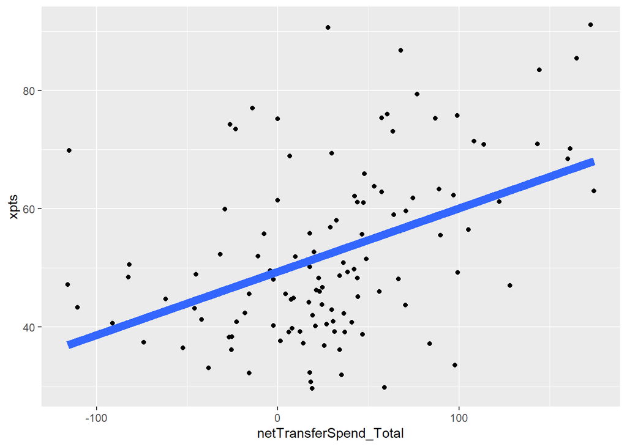

```r
finalData %>% ggplot(aes(x = netTransferSpend_Total, y = xpts)) +
  geom_point() +
  geom_smooth(method = "lm", se = F, size = 3)
```